# Homework 1

Author

Ethan Lee

## Homework 1

For this assignment, you may use R or Python, or a combination of both, to complete both case studies. You can use the code that we include in Labs 1 and 2 to answer these questions. You also may need to use other functions. I encourage you to make use of our textbook(s) and use the Internet to help you solve these problems. You can also work together with your classmates. If you do work together, you should provide the names of those classmates below.

[Names of Collaborators (if any):]N/A

### Case Study: New York Times Ad Impressions (Simulated)

There are 10 data sets in the `/data` subdirectory named `nyt1.csv`, `nyt2.csv`, …, `nyt10.csv`. Each file represents one day’s worth of simulated data on ad impressions and clicks on the [New York Times homepage](https://www.nytimes.com/). Each row represents a single user. There are five columns:

- `Age` (user’s age)
- `Gender` (user’s gender, coded as `0` = female, `1` = male)
- `Impressions` (number of ads displayed during the user’s visit)
- `Clicks` (number of clicks made by the user)
- `Signed_In` (whether or not the user was signed in as a member)

Load **a single data file**. Then do the following.

```r
nyt_data <- read.csv("data/nyt1.csv")
```

1. Create a new variable, `age_group`, that categorizes users into the following age groups: < 18, 18-24, 25-34, 35-44, 45-54, 55-64, and 65+.

```r
nyt_data$age_group <- cut(nyt_data$Age, breaks = c(0, 17, 24, 34, 44, 54, 64, Inf),
                 labels = c("<18", "18-24", "25-34", "35-44", "45-54", "55-64", "65+"),
                 include.lowest = TRUE)
```

2. Plot the distributions of impressions and “click-through rate” for all 6 age categories. (*Note:* Click-through rate is defined as the number of clicks divided by the number of impressions; it represents the proportion of ads that generated clicks.)

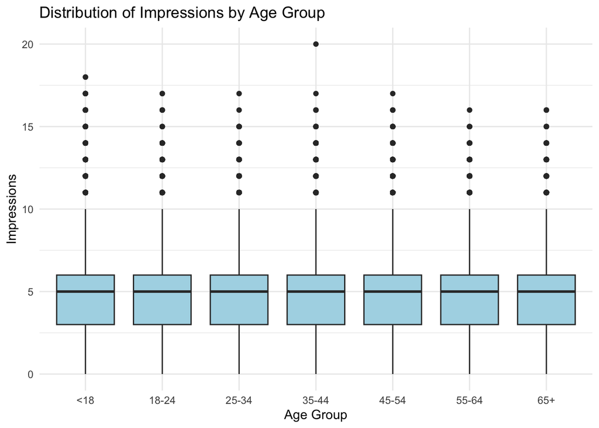

```r
library(ggplot2)
ggplot(nyt_data, aes(x = age_group)) +
  geom_boxplot(aes(y = Impressions), fill = "lightblue") +
  labs(title = "Distribution of Impressions by Age Group", x = "Age Group", y = "Impressions") +
  theme_minimal()
```

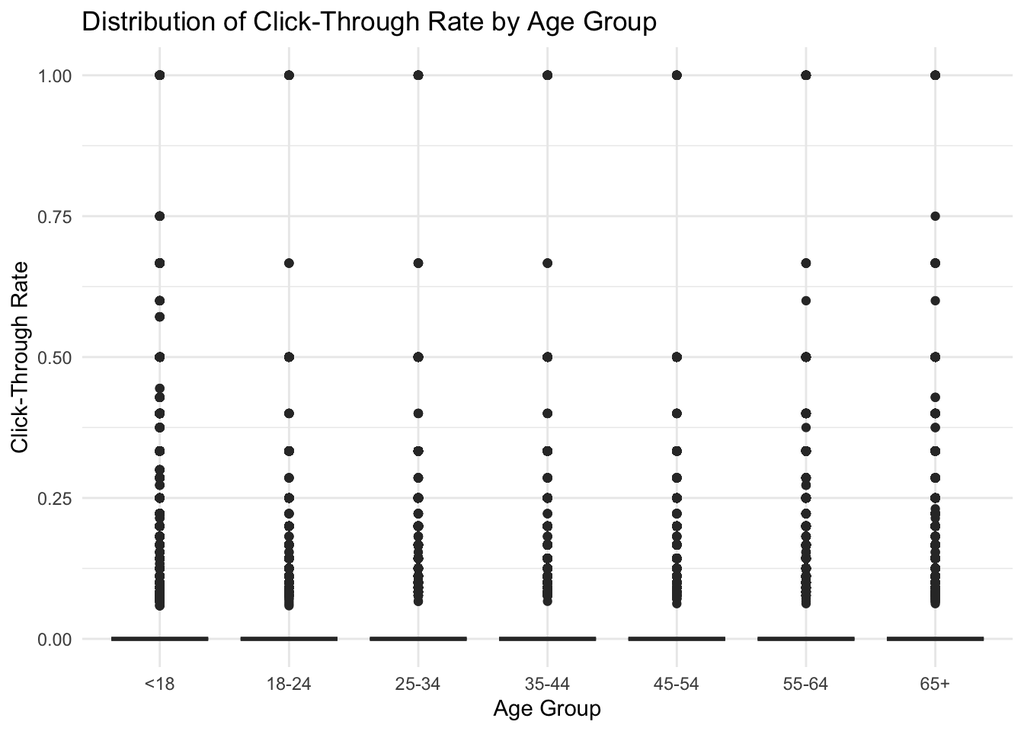

```r
# since click through rate divides clicks by impressions, we need to remove observations that have Impressions = 0 to avoid division by zero
ctr_data <- subset(nyt_data, Impressions > 0)
ctr_age_group <- cut(ctr_data$Age, breaks = c(0, 17, 24, 34, 44, 54, 64, Inf),
                 labels = c("<18", "18-24", "25-34", "35-44", "45-54", "55-64", "65+"),
                 include.lowest = TRUE)
ctr_data$click_through_rate <- ctr_data$Clicks / ctr_data$Impressions

ggplot(ctr_data, aes(x = ctr_age_group)) +
  geom_boxplot(aes(y = click_through_rate), fill = "lightgreen") +
  labs(title = "Distribution of Click-Through Rate by Age Group", x = "Age Group", y = "Click-Through Rate") +
  theme_minimal()
```

3. Create a new variable to categorize users based on their click behavior. (The name and categories for this variable are up to you. Explain what decision[s] you make and why.)

```r
ctr_data$click_behavior <- cut(ctr_data$click_through_rate, breaks = c(-Inf, 0, 0.1, 0.5, Inf),
                                labels = c("No Clicks", "Low Click-Through", "Moderate Click-Through", "High Click-Through"))
# I chose to this categorization because it allows us to differentiate between users who are not engaging with ads at all, those who engage minimally, those who engage moderately, and those who engage heavily. It provides a more descriptive understanding of user behavior than categorizing users as clickers or non-clickers.
```

4. Explore the data and make visual and quantitative comparisons across user segments/demographics to answer the following:
   - How do <18 year old males differ from <18 year old females in terms of clicks and impressions?
   - How does the distribution of click-through rate for users who are signed in differ from the distribution for those who are **not** signed in?
   - Are certain age groups more likely to be signed in than others? Which ones?

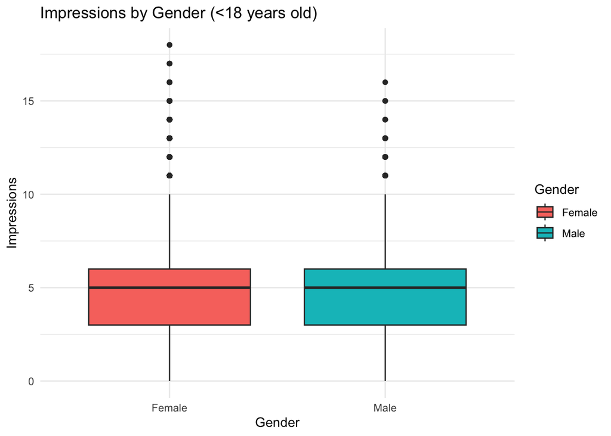

```r
# under 18 males vs females
library(dplyr)
under_18 <- subset(nyt_data, age_group == "<18")
under_18$Gender <- factor(under_18$Gender,
                                 levels = c(0, 1),
                                 labels = c("Female", "Male"))

ggplot(under_18, aes(x = Gender, y = Impressions, fill = Gender)) +
  geom_boxplot() +
  labs(title = "Impressions by Gender (<18 years old)", x = "Gender", y = "Impressions") +
  theme_minimal()
```

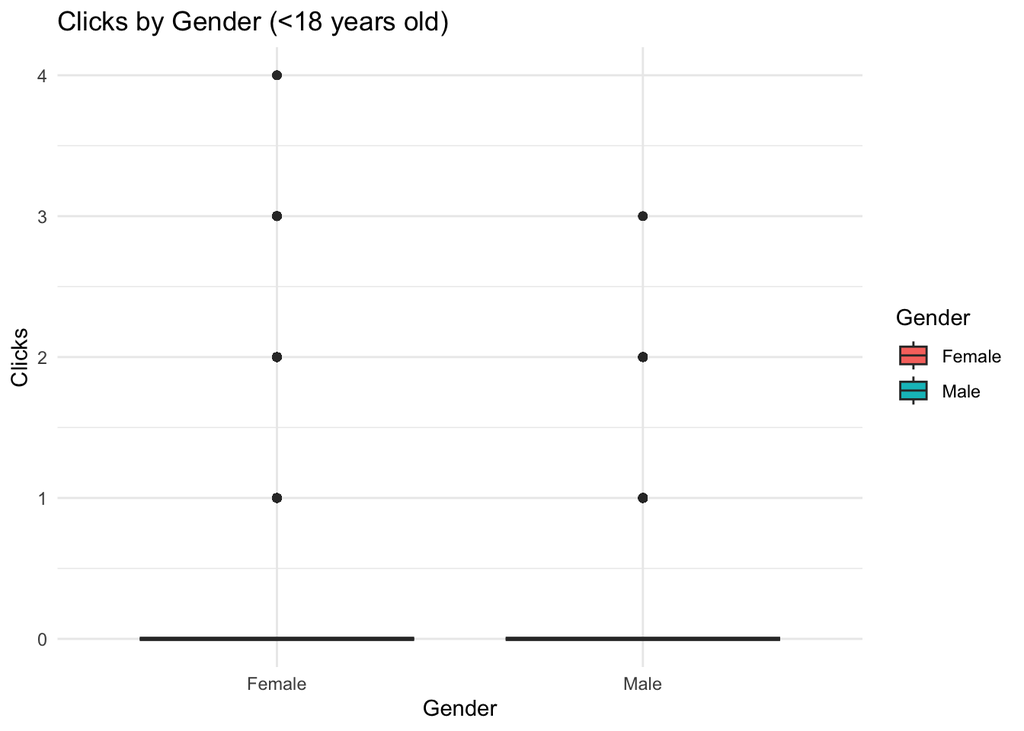

```r
ggplot(under_18, aes(x = Gender, y = Clicks, fill = Gender)) +
  geom_boxplot() +
  labs(title = "Clicks by Gender (<18 years old)", x = "Gender", y = "Clicks") +
  theme_minimal()
```

```r
under_18 %>%
  group_by(Gender) %>%
  summarize(
    mean_impressions = mean(Impressions),
    mean_clicks = mean(Clicks)
  )
```

```
# A tibble: 2 × 3
  Gender mean_impressions mean_clicks
  <fct>             <dbl>       <dbl>
1 Female             5.00       0.143
2 Male               5.01       0.146
```

```r
# I used AI for the quantitative comparison, it suggested that I could use the summarize funciton in combination wiht group_by to easily compare males and females under 18 in terms of their average impressions and clicks.

# Males and females under 18 years old are quite similar in their impressions and clicks. The quantitative comparison shows this very well, as the average number of clicks and impressions is almost identical between males and females.
```

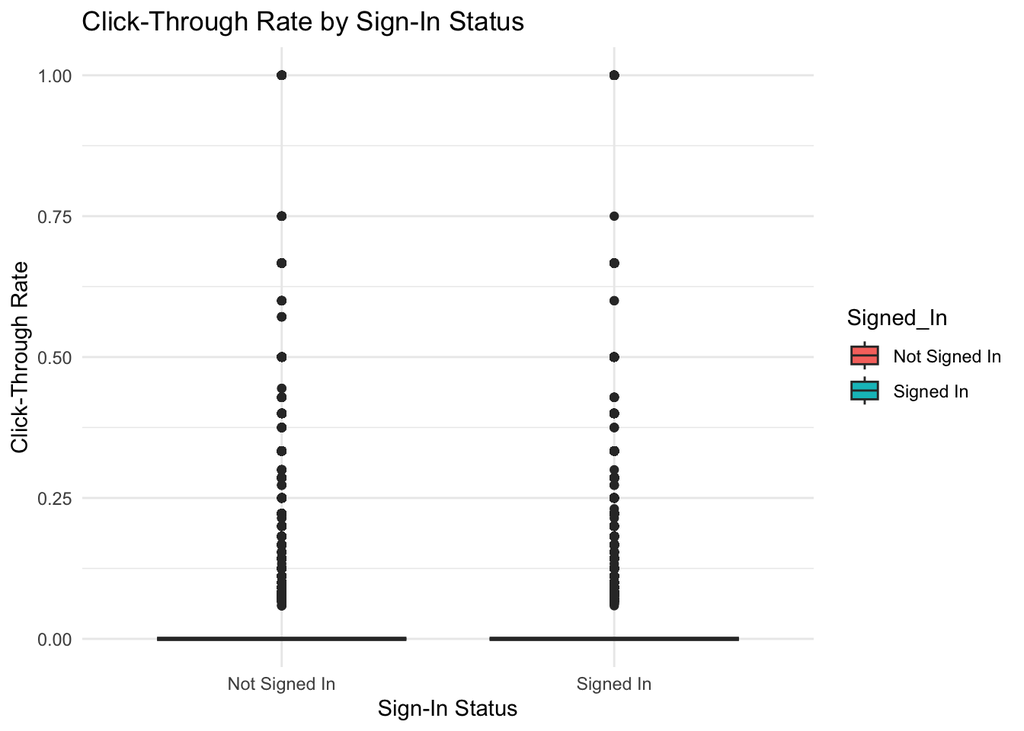

```r
# signed in vs not signed in
ctr_data$Signed_In <- factor(ctr_data$Signed_In,
                                 levels = c(0, 1),
                                 labels = c("Not Signed In", "Signed In"))

ggplot(ctr_data, aes(x = Signed_In, y = click_through_rate, fill = Signed_In)) +
  geom_boxplot() +
  labs(title = "Click-Through Rate by Sign-In Status", x = "Sign-In Status", y = "Click-Through Rate") +
  theme_minimal()
```